# Final Project

```r
scheme2 <- evaluationScheme(beers_rrmatrix, method = "cross-validation",k = 5, given = -1, goodRating = 4)
scheme2
```

```
## Evaluation scheme using all-but-1 items
## Method: 'cross-validation' with 5 run(s).
## Good ratings: >=4.000000
## Data set: 4902 x 3235 rating matrix of class 'realRatingMatrix' with 698288 ratings.
```

## Building IBCF and UBCF models with below hyperparameters

```r
algorithms <- list(
  "user-based CF" = list(name="UBCF", param=list(normalize = "Z-score",
                                                 method="Cosine",
                                                 nn=30)),
  "item-based CF" = list(name="IBCF", param=list(normalize = "Z-score")))
```

## Evaluating algorithms & predicting next n beers

```r
results1 <- evaluate(scheme1, algorithms, n=c(1, 3, 5, 10, 15, 20))
```

```
## UBCF run fold/sample [model time/prediction time]
##   1  [0.2sec/80.53sec]
## IBCF run fold/sample [model time/prediction time]
##   1  [183.16sec/0.94sec]
```

```r
class(results1)
```

```
## [1] "evaluationResultList"
## attr(,"package")
## [1] "recommenderlab"
```

```r
results2 <- evaluate(scheme2, algorithms, n=c(1, 3, 5, 10, 15, 20))
```

```
## UBCF run fold/sample [model time/prediction time]
##   1  [0.17sec/66.06sec]
##   2  [0.17sec/66.76sec]
##   3  [0.21sec/66.38sec]
##   4  [0.18sec/66.68sec]
##   5  [0.18sec/68.5sec]
## IBCF run fold/sample [model time/prediction time]
##   1  [193.78sec/0.83sec]
##   2  [189.95sec/0.8sec]
##   3  [186.2sec/0.74sec]
##   4  [198.35sec/0.72sec]
##   5  [195.73sec/0.72sec]
```

```r
class(results2)
```

```
## [1] "evaluationResultList"
## attr(,"package")
## [1] "recommenderlab"
```

## Compare the performance of the two models and suggest the one that should be deployed

Drawing ROC curve

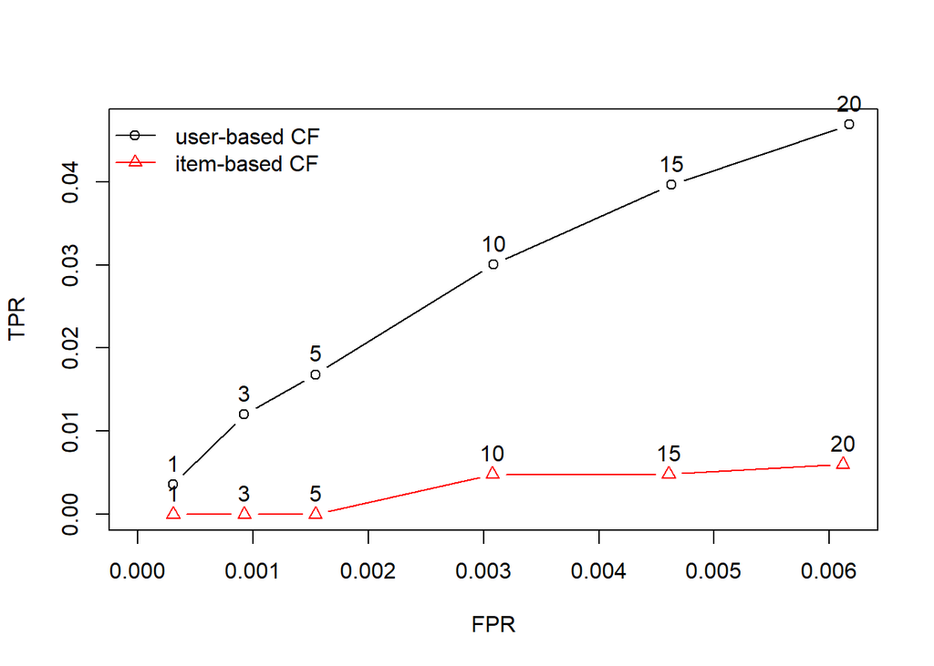

```r
plot(results1, annotate = 1:4, legend="topleft")
```

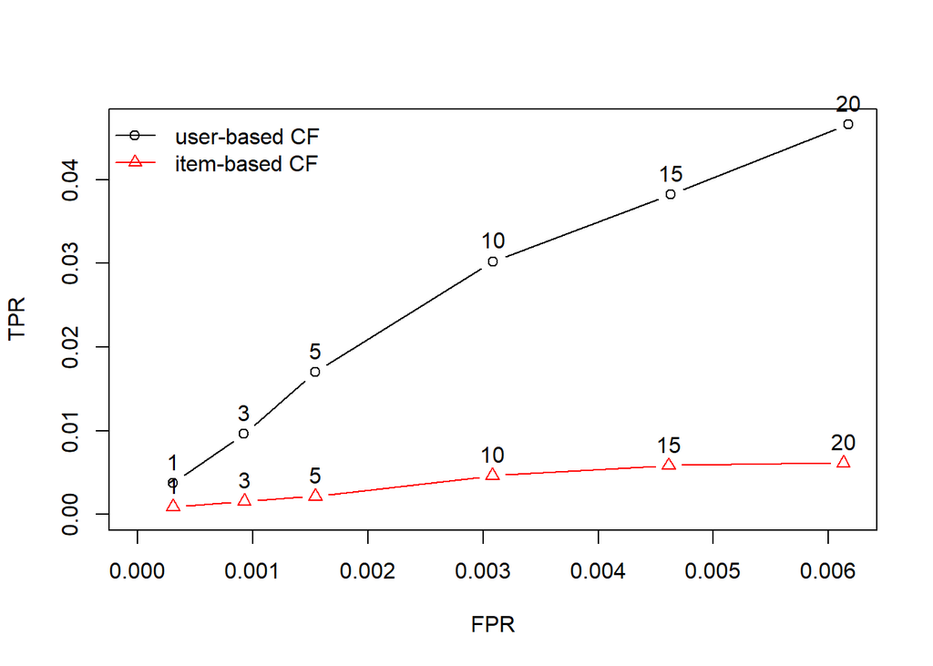

```r
plot(results2, annotate = 1:4, legend="topleft")
```

#### As we have already proved, UBCF is better than IBCF especially with higher values of n.

# Give the names of the top 5 beers that you would recommend to the any 3 users (randomly picked)

```r
r <- Recommender(beers_rrmatrix, method = "UBCF")
r
```

```
## Recommender of type 'UBCF' for 'realRatingMatrix'
## learned using 4902 users.
```

For stcules

```r
recom_cokes <- predict(r, beers_rrmatrix['stcules'], n=5)
as(recom_cokes, "list")
```

```
## $stcules
## [1] "16814" "29619" "1904"  "11757" "46849"
```

For johnmichaelsen

```r
recom_genog <- predict(r, beers_rrmatrix['johnmichaelsen'], n=5)
as(recom_genog, "list")
```

```
## $johnmichaelsen
## [1] "248"   "141"   "28268" "672"   "15589"
```

For oline73

```r
recom_giblet <- predict(r, beers_rrmatrix['oline73'], n=5)
as(recom_giblet, "list")
```

```
## $oline73
## [1] "104"  "1696" "226"  "2810" "101"
```